# sNMF program with LEA package (admixture) for a worldwide collection of *Zymoseptoria tritici*

Silvia Minana Posada

2023-05-22

This script is to use the sNMF that is quite similar to ADMIXTURE software but faster through the LEA package in BioConductor.

#### Population structure –> Admixture

The clustering here is done by using the sNMF method from the LEA R package (http://membres-timc.imag.fr/Olivier.Francois/LEA/) on the same subset of SNPs as the PCA. It was done for 1 to 15 K with 10 repetitions, as it was done in Alice Feurtey GitHub.

```r
#ped file created from vcf.gz using vcftools removing mitochondria
file="newgenofile"


indv_snmf = read_tsv("thinnedplusmaf.ind", col_names = F)
names(indv_snmf) = "ID_genome_file"

coorandcont<-read.csv("WP1_SMP_Coordandvariety_contlocextralat_20240826_v1.csv", sep=",", header=TRUE)

anti_join(indv_snmf, coorandcont)
```

```
## # A tibble: 0 × 1
## # ℹ 1 variable: ID_genome_file <chr>
```

```r
anti_join(coorandcont, indv_snmf)
```

```
##   Isolate_full_name_phenotyping             ID_genome_file Latitude Longitude
## 1         Oregon_1990_a12_3B_13          ST90ORE_a12_3B_13  44.5646 -123.2620
## 2       Texas_1994_ST94TXPF4a_1   Texas_1994_ST94TX_PF4a_1  33.2362  -96.8011
## 3    Tunisia_2008_ST08TN_33_1_2 Tunisia_2008_ST08TN_33_1_2  36.7333    9.1844
## 4               Yemen_1992_YEQ1                   ST92YE_1  15.3710   44.2078
##                               Variety Location                  Country
## 1 Malcolm__Madsen__Stephens__OR830001   Oregon United_States_of_America
## 2                                <NA>    Texas United_States_of_America
## 3                  Mostly_Durum_wheat  Tunisia                  Tunisia
## 4                         Bread_wheat    Yemen                    Yemen
##   Geographic_region Year Location_year     New_Location_year
## 1     North_America 1990   Oregon_1990 USA_Corvallis_OR_1990
## 2     North_America 1994    Texas_1994        USA_Prosper_TX
## 3            Africa 2008  Tunisia_2008          Tunisia_Beja
## 4       Middle_East 1992    Yemen_1992                 Yemen
```

```r
allstraincoorandcont<-inner_join(indv_snmf, coorandcont)
#geno<-read.geno("thinnedplusmaf.geno")
#write.geno(geno, "newgenofile.geno")

#Estimation of the ancestral individual coefficients and the frequences of the ancestral alleles

#obj.snmf <- snmf(paste0(file, ".geno"), K=1:15, project="new", entropy=TRUE, rep=10, ploidy=1)

#Load project
project = load.snmfProject(paste(file,".snmfProject", sep=""))
summary(project)
```

```
## $repetitions
##                       K = 1 K = 2 K = 3 K = 4 K = 5 K = 6 K = 7 K = 8 K = 9
## with cross-entropy       10    10    10    10    10    10    10    10    10
## without cross-entropy     0     0     0     0     0     0     0     0     0
## total                    10    10    10    10    10    10    10    10    10
##                       K = 10 K = 11 K = 12 K = 13 K = 14 K = 15
## with cross-entropy        10     10     10     10     10     10
## without cross-entropy      0      0      0      0      0      0
## total                     10     10     10     10     10     10
##
## $crossEntropy
##          K = 1     K = 2     K = 3     K = 4     K = 5     K = 6     K = 7
## min  0.4610857 0.4311797 0.4043161 0.3929384 0.3872126 0.3816722 0.3788638
## mean 0.4623311 0.4325156 0.4053130 0.3939960 0.3883743 0.3834871 0.3803691
## max  0.4633524 0.4336559 0.4064688 0.3951577 0.3906574 0.3867718 0.3815761
##          K = 8     K = 9    K = 10    K = 11    K = 12    K = 13    K = 14
## min  0.3761315 0.3744164 0.3727209 0.3711670 0.3698217 0.3689542 0.3684685
## mean 0.3779782 0.3758961 0.3740026 0.3724922 0.3709915 0.3708580 0.3700872
## max  0.3792095 0.3766658 0.3751440 0.3736851 0.3724510 0.3727444 0.3719244
##         K = 15
## min  0.3681485
## mean 0.3693213
## max  0.3706895
```

```r
K_list = c(1:15)

#Extracting the clustering info for the best run per K
datalist = list()
for (i in K_list){
  best = which.min(cross.entropy(project, K = i))
  temp = as.data.frame(Q(project, i, best))
  temp= cbind(indv_snmf, temp)

  temp = temp %>%
    gather("Cluster", "Admix_coef", -"ID_genome_file") %>%
    mutate(K=i)
   datalist[[i]] = as.tibble(temp)
}
```

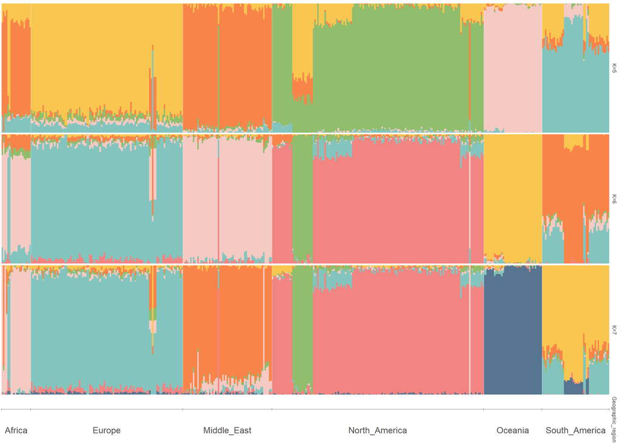

```r
snmf_results_per_K = bind_rows(datalist) %>%
  inner_join(., allstraincoorandcont) %>%
  unite(Geographic_region, Location_year, col = "for_display", remove = F)
afiles = character(length(K_list))
for (i in K_list){
  best = which.min(cross.entropy(project, K = i))
  afiles[i] = Sys.glob(paste0(file, ".snmf/K",i, "/run", best, "/*Q"))
}


# create a qlist
qlist <- readQBasic(afiles)
al_qlist = alignK(qlist)

lab_set = allstraincoorandcont %>%
  dplyr::select(Geographic_region) %>%
  mutate(Geographic_region = ifelse(is.na(Geographic_region), "Unknown", Geographic_region))

K_colors = c("#f9c74f", "#f9844a", "#90be6d", "#f5cac3",
"#83c5be", "#f28482", "#577590", "#e5e5e5", "#a09abc",  "#52796f",
"#219ebc", "#003049", "#82c0cc", "#283618", "white")

#Low numbers
from = 5
up_to = 7
p1 <-   plotQ(alignK(qlist[from:up_to], type = "across"),
            imgoutput="join",
            returnplot=T,exportplot=F,
            basesize=11,
            splab= paste0("K=", K_list[from:up_to]),
            grplab=lab_set, ordergrp=T, grplabheight = 2, grplabsize = 5,
            clustercol = K_colors)

grid.arrange(p1$plot[[1]])
```

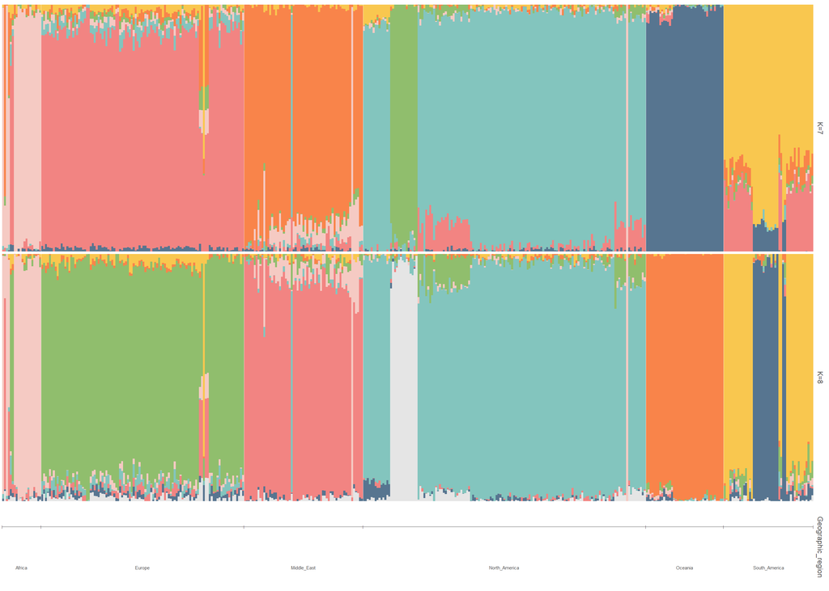

```r
#Medium numbers
from = 7
up_to = 8
p2 <-   plotQ(alignK(qlist[from:up_to], type = "across"),
            imgoutput="join",
            returnplot=T,exportplot=F,
            basesize=11,
            splab= paste0("K=", K_list[from:up_to]),
            grplab=lab_set, ordergrp=T,  grplabheight = 2, grplabsize = 2,
            clustercol = K_colors)
grid.arrange(p2$plot[[1]])
```

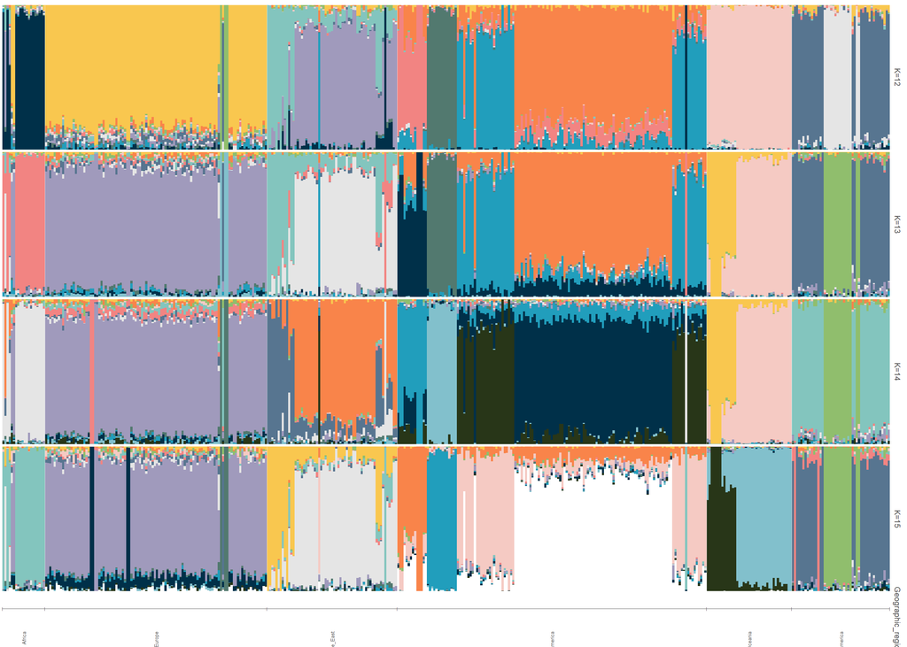

```r
#High numbers
from = 12
up_to = 15
p3 <-   plotQ(alignK(qlist[from:up_to], type = "across"),
            imgoutput="join",
            returnplot=T,exportplot=F,
            basesize=11,
            splab= paste0("K=", K_list[from:up_to]),
            grplab=lab_set, ordergrp=T, grplabangle = 90, grplabheight = 2, grplabsize = 2,
            clustercol = K_colors)
grid.arrange(p3$plot[[1]])
```

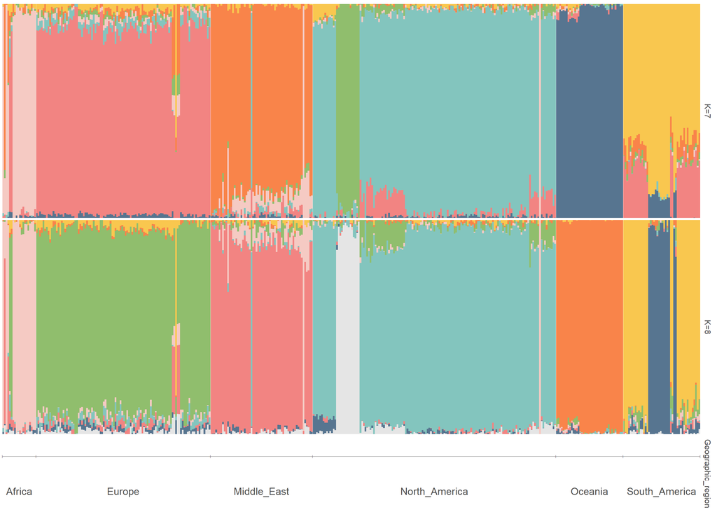

```r
from = 7
up_to = 8
p3 <-   plotQ(alignK(qlist[from:up_to], type = "across"),
            imgoutput="join",
            returnplot=T,exportplot=F,
            basesize=14,
            splab= paste0("K=", K_list[from:up_to]),
            grplab=lab_set, ordergrp=T, grplabangle = 0, grplabheight = 2, grplabsize = 5,
            clustercol = K_colors)

grid.arrange(p3$plot[[1]])
```

I need to identify the isolates which belong to each of the clusters. For this, we need to set a threshold, since there are very few (or even no) isolates assigned fully to one only. I test two thresholds: isolates assigned to one cluster with a value higher than 0.75 and 0.9.

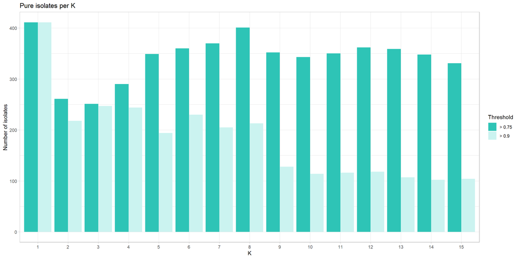

```r
isolateswrongstructure<-c("Ukraine_1995_ST95UR_F1c_1", "Israel_1992_ISZE2a_2", "Texas_1994_ST94TXPG7a_1", "Kenya_1994_STKE94ML1a", "Kenya_1994_STKE94MF1a")
missing20rem<-c("Texas_1994_ST94TX_PF4a_1", "Tunisia_2008_ST08TN_33_1_2", "ST90ORE_a12_3B_13", "ST92YE_1")
snmf_results_per_K<-snmf_results_per_K %>% filter(!(ID_genome_file %in% isolateswrongstructure)) %>% filter(!(ID_genome_file %in% missing20rem))

#Setting thresholds to compare
chosen_threshold = 0.75
chosen_threshold2 = 0.9

pure_by_threshold = bind_rows(snmf_results_per_K %>%
    filter(Admix_coef > chosen_threshold) %>%
    mutate(Threshold = paste0("> ", chosen_threshold)),
  snmf_results_per_K %>%
    filter(Admix_coef > chosen_threshold2) %>%
    mutate(Threshold = paste0("> ", chosen_threshold2)))


# Number of pure isolates per K
pure_by_threshold %>%
    dplyr::group_by(K, Threshold) %>%
    dplyr::count() %>%
    ggplot(aes(x = as.factor(K), y = n, fill = Threshold)) +
       geom_bar(stat = "identity", position = "dodge") +
       theme_light() + scale_fill_manual(values = c("#2ec4b6", "#cbf3f0"))+
    labs(x = "K", y = "Number of isolates", title = "Pure isolates per K")
```

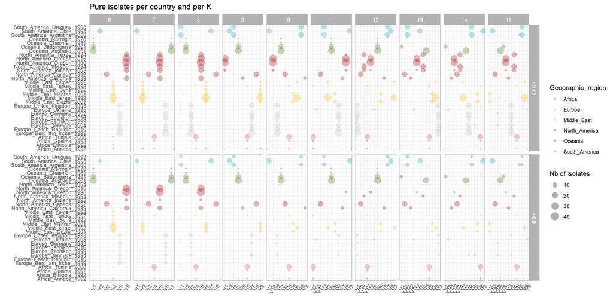

```r
# Number of pure isolates per K per country
temp2 = pure_by_threshold %>%
  dplyr::group_by(Geographic_region, for_display, Cluster, K, Threshold) %>%
  dplyr::count() %>% ungroup() %>% group_by(Geographic_region, Cluster, K, Threshold) %>%
  mutate(freq = n / sum(n))

myColors <- c("#DA4167", "grey", "#ffba0a", "#A20106", "#3F6E0C", "#129eba", "#8fa253" )
names(myColors) = levels(factor(allstraincoorandcont$Geographic_region))
Color_Geographic_region = ggplot2::scale_colour_manual(name = "Geographic_region", values = myColors)
Fill_Geographic_region = ggplot2::scale_fill_manual(name = "Geographic_region", values = myColors)


temp2 %>%
  filter(K > 5 & K < 16) %>%
  ggplot(aes(x = Cluster, y = for_display, size = n, color = Geographic_region)) +
  geom_point(alpha = 0.3) + Color_Geographic_region+ theme_light() +
  theme(axis.text.x = element_text(angle = 60, hjust = 1)) +
  facet_grid(rows = vars(Threshold), cols = vars(K), scales = "free_x") +
    labs(x = "", y = "", size = "Nb of isolates",
         title = "Pure isolates per country and per K")
```

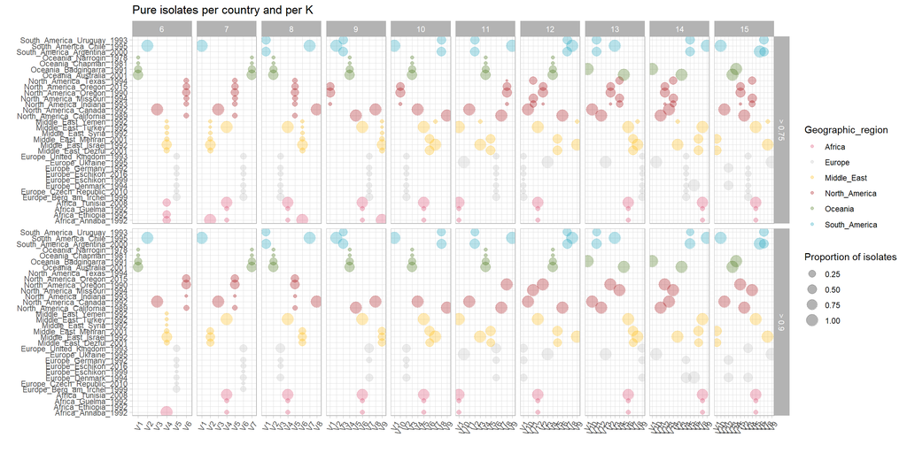

```r
temp2 %>%
  filter(K > 5 & K < 16) %>%
  ggplot(aes(x = Cluster, y = for_display, size = freq, color = Geographic_region)) +
  geom_point(alpha = 0.3) + Color_Geographic_region+ theme_light() +
  theme(axis.text.x = element_text(angle = 60, hjust = 1)) +
  facet_grid(rows = vars(Threshold), cols = vars(K), scales = "free_x") +
    labs(x = "", y = "", size = "Proportion of isolates",
         title = "Pure isolates per country and per K")
```